# Publikationssystem transformieren

15. Juni 2021

## Registered Reports

### Was sind RR?

**Klassisches Publikationsformat:**

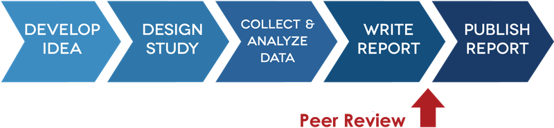

(cos.io/rr)

(Chambers et al., 2014)

## Registered Reports

### Was sind RR?

**Registered Report:**

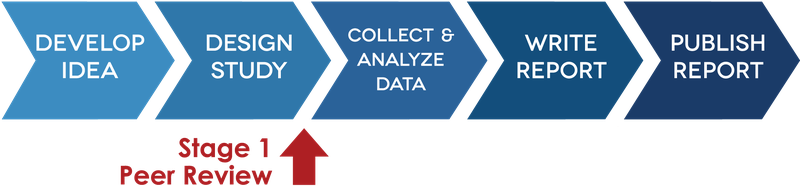

(cos.io/rr)

(Chambers et al., 2014)

## Registered Reports

### Was sind RR?

**Registered Report:**

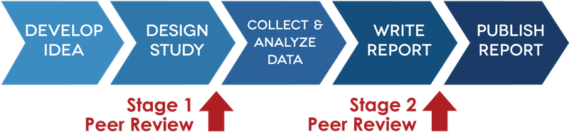

(cos.io/rr)

(Chambers et al., 2014)

## Registered Reports

### Warum RR?

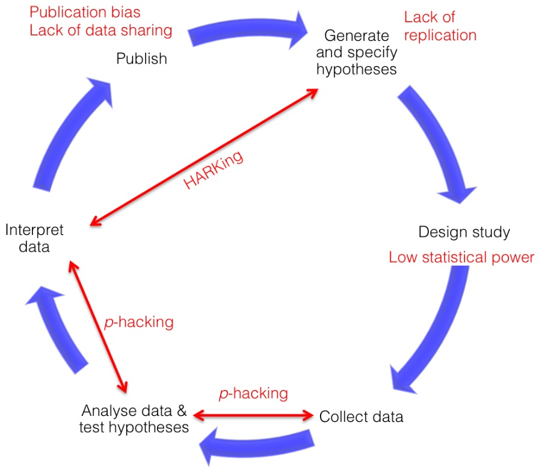

**Questionable Research Practices**

- Selektives Berichten (AVs, Bedingungen, Studien)
- Sequenzielle Datenerhebung/ Optionales Stoppen
- Exkludieren von Fällen
- HARKing
- Exploration als Konfirmation markieren
- …

(John et al., 2012; Simmons et al., 2011)

## Registered Reports

### Wo?

**Zeitschriften** (beispielhaft):

- Learning and Instruction
- British Journal of Educational Psychology
- Frontiers in Education
- Journal of Educational Psychology
- Zeitschrift für Bildungsforschung
- …

Für eine vollständigere Liste: cos.io/initiatives/registered-reports

## Registered Reports

### Tipps & Guidelines

- Checkliste für eine erfolgreiche Einreichung: osf.io/93znh/
- “Practical Considerations”  
  (Kiyonaga & Scimeca, 2019)

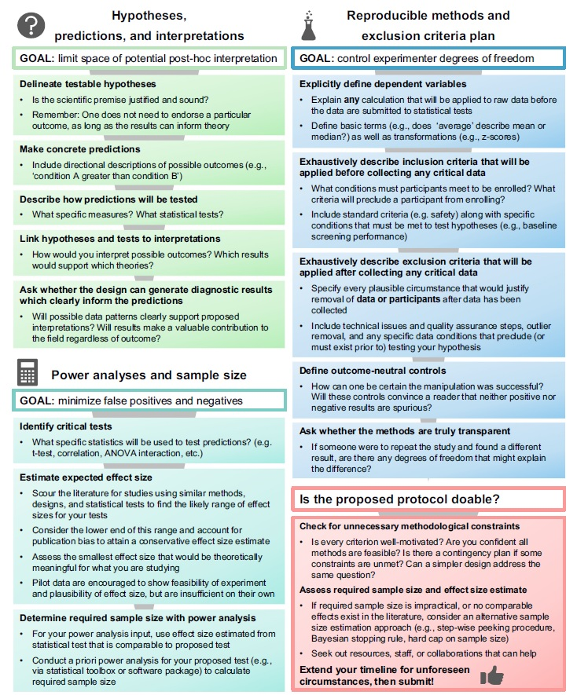

## Publikation & Evaluation entkoppeln

### Was?

**Klassisch**

- Zeitschrift: Publikation & Evaluation

**Entkopplung**

- direkte Publikation des Artikels (über Zeitschrift oder Repository)
- Evaluation des Manuskripts
  - durch Zeitschriften (potentiell auch mehrere)
  - durch Review Services

## Publikation & Evaluation entkoppeln

### Warum?

- File-drawer effect  
  (Rosenthal, 1979)
- Publikationszeiten verkürzen  
  (z.B. bei Arbeit unter Zeitdruck während einer Pandemie; Kwon, 2020)

## Publikation & Evaluation entkoppeln

### Wie?

**Publikation von Preprints**

[figure not shown]

**Review**

## Open Peer Review

### Was?

Merkmale:

- **Identitäten** der Reviewer*innen/ Autor*innen offen
- **Inhalte** der Reviews offen
- **Antworten** der Autor*innenen offen
- offen für erweiterte **Community**
- **Zeitpunkt** offen

## Open Peer Review

### Warum?

**Vorteile**

- Anerkennung der Leistung für Reviewende (Anreizstrukturen)
- potenzielle konkurrierende Interessen/ biased gatekeeping leichter erkennbar
- Schnelligkeit der Dissemination (preprint oft nicht möglich bei blind review) (Wang, 2016)

**Unklar**

- Qualität des Feedbacks?
  - Keine Unterschiede in Review-Qualität, Review-Empfehlung und Zeit der Anfertigung des Reviews (signed review: van Rooyen et al., 1999, öffentliches posten: 2010)
  - Höhere Qualität, konstruktiver, längere Bearbeitungszeit, Review-Empfehlnug tendenziell positiver (Walsh et al., 2000)

## Open Peer Review

### Warum?

**Nachteile**

- fehlende Standards
- Geringere Reviewquote (van Rooyen et al., 1999)
- negative Folgen kritischer Gutachten ggü. etablierten Forscher*innen?

## Open Peer Review

### Beispiele

**Collabra: Psychology**:  
Veröffentlichung der double-blind Reviews ohne Namen der Reviewenden bei Publikation (Supplemental Material)

**PLOS ONE/ Frontiers in Education**:  
Kommentierung durch Peers (Kommentarfunktion)

**F1000**:

- Veröffentlichung der “signed” Reviews
- Veröffentlichung der Antworten
- Kommentierung durch Peers

[(Aleksic et al., 2015)](https://f1000research.com/articles/3-271/v2)

Chambers, C. D., Feredoes, E., D. Muthukumaraswamy, S., J. Etchells, P., & 1 Cardiff University Brain Research Imaging Centre, School of Psychology, Cardiff University; (2014). Instead of “playing the game” it is time to change the rules: Registered Reports at AIMS Neuroscience and beyond. *AIMS Neuroscience*, *1*(1), 4–17. https://doi.org/10.3934/Neuroscience.2014.1.4

John, L. K., Loewenstein, G., & Prelec, D. (2012). Measuring the Prevalence of Questionable Research Practices With Incentives for Truth Telling. *Psychological Science*, *23*(5), 524–532. https://doi.org/10.1177/0956797611430953

Kiyonaga, A., & Scimeca, J. M. (2019). Practical Considerations for Navigating Registered Reports. *Trends in Neurosciences*, *42*(9), 568–572. https://doi.org/10.1016/j.tins.2019.07.003

Kwon, D. (2020). How swamped preprint servers are blocking bad coronavirus research. *Nature*, *581*(7807), 130–131. https://doi.org/10.1038/d41586-020-01394-6

Rosenthal, R. (1979). The file drawer problem and tolerance for null results. *Psychological Bulletin*, *86*(3), 638–641. https://doi.org/10.1037/0033-2909.86.3.638

Simmons, J. P., Nelson, L. D., & Simonsohn, U. (2011). False-Positive Psychology: Undisclosed Flexibility in Data Collection and Analysis Allows Presenting Anything as Significant. *Psychological Science*, *22*(11), 1359–1366. https://doi.org/10.1177/0956797611417632

van Rooyen, S., Delamothe, T., & Evans, S. J. W. (2010). Effect on peer review of telling reviewers that their signed reviews might be posted on the web: Randomised controlled trial. *BMJ*, *341*(nov16 2), c5729–c5729. https://doi.org/10.1136/bmj.c5729

van Rooyen, S., Godlee, F., Evans, S., Black, N., & Smith, R. (1999). Effect of open peer review on quality of reviews and on reviewers’ recommendations: A randomised trial. *BMJ*, *318*(7175), 23–27. https://doi.org/10.1136/bmj.318.7175.23

Walsh, E., Rooney, M., Appleby, L., & Wilkinson, G. (2000). Open peer review: A randomised controlled trial. *British Journal of Psychiatry*, *176*(1), 47–51. https://doi.org/10.1192/bjp.176.1.47

Wang, P. (2016, March). Open Peer Review: An Innovation in Scientific Publishing. *iConference 2016 Proceedings*. https://doi.org/10.9776/16315

**Images**  
(in order of appearance)

title page | [Jess Bailey](https://unsplash.com/@jessbaileydesigns?utm_source=unsplash&utm_medium=referral&utm_content=creditCopyText) on [Unsplash](https://unsplash.com/?utm_source=unsplash&utm_medium=referral&utm_content=creditCopyText)  
icons | [fontawesome.com CC-BY 4.0](https://fontawesome.com/license/free) (icons used throughout the slides)

**License**  
This work is licensed under a [Creative Commons Attribution-ShareAlike 4.0 International License](http://creativecommons.org/licenses/by-sa/4.0/).